# Autocorrelation in Climate

2017-10-11

```r
# Load packages and make connections to babase
Sys.setenv(TZ = 'UTC')
list.of.packages <- list("devtools", "viridis", "tidyverse", "stringr",
                         "lubridate")
new.packages <- list.of.packages[!(list.of.packages %in% installed.packages()[,"Package"])]
if (length(new.packages)) install.packages(unlist(new.packages))
lapply(list.of.packages, require, character.only = T)

# Check if ramboseli already installed
if (!("ramboseli" %in% installed.packages()[,"Package"])) {
  devtools::install_github("amboseli/ramboseli")
}
library(ramboseli)
```

## Obtain weather data from babase

```r
# You will need to change user to your personal babase login AND get your password
# One approach to doing that is through Rstudio
# You could also just type it in your script, but that's not recommended for security.
babase <- DBI::dbConnect(RPostgreSQL::PostgreSQL(),
                         host = "localhost",
                         port = 2222,
                         user = "YOUR_BABASE_USERNAME",
                         dbname = "babase",
                         password = rstudioapi::askForPassword("Database password"))

# Pull rainfall data from babase
wreadings <- tbl(babase, "wreadings") %>% collect()
raingauges <- tbl(babase, "raingauges") %>% collect()
```

## Summarise rainfall data

```r
# Join the tables
rain <- inner_join(wreadings, raingauges, by = "wrid")

# Create date columns
rain <- make_date_cols(rain, wrdaytime)
rain$date_of <- as.Date(rain$wrdaytime)

# There is one weird case of two rainfall measurements taken on the same day
# 2010-11-05
# Add all measurements taken on same date
rain <- rain %>%
  group_by(year_of, month_of, date_of) %>%
  summarise(rain = sum(rain)) %>%
  ungroup()
```

### Monthly totals, long-term monthly means, and anomalies

```r
# Calculate monthly totals
rain_monthly <- rain %>%
  group_by(year_of, month_of) %>%
  summarise(rain_monthly = sum(rain)) %>%
  ungroup()

# Calculate monthly long-term means
rain_ltm <- rain_monthly %>%
  group_by(month_of) %>%
  summarise(rain_ltm = mean(rain_monthly)) %>%
  ungroup()

# Calculate monthly rainfall anomaly by subtracting long-term mean
rain_monthly <- rain_monthly %>%
  inner_join(rain_ltm, by = "month_of") %>%
  mutate(rain_anomaly = rain_monthly - rain_ltm)

# Create dummy date for each month (~middle of month)
rain_monthly <- rain_monthly %>%
  mutate(date_of = ymd(paste(year_of, month_of, "16", sep = "-")))
```

### Annual totals

```r
# Calculate annual rainfall total
rain_annual <- rain %>%
  group_by(year_of) %>%
  summarise(rain_annual = sum(rain))
```

## Autocorrelation functions

### Monthly rainfall totals

This first example illustrates how the autocorrelation function works. It is the correlation between the time series of monthly rainfall values and itself offset by different time steps, called lags. In the plots below, significant autocorrelations appear as red-highlighted segments that extend out of the red-shaded critical region.

In this example, we see the pattern that we would expect in any location *where rainfall patterns are strongly seasonal*. Specifically, we see highly significant positive autocorrelation at time lags that whole years apart (1, 2, 3, …). This is because, for any given month, rainfall patterns will be broadly similar across years during that month (e.g., July is nearly always dry in Amboseli, December is nearly always wet, etc.). We see decaying positive autocorrelation at lags close to whole years because adjacent months are typically part of the same season, and this relationship clearly weakens as you move farther from the whole years. We also see significant negative correlation at half-year lags (0.5, 1.5, 2.5, …). This reflects the oscillation between wet and dry seasons.

None of this is particularly interesting, as it’s exactly what you would expect, but it may help to clarify the results below.

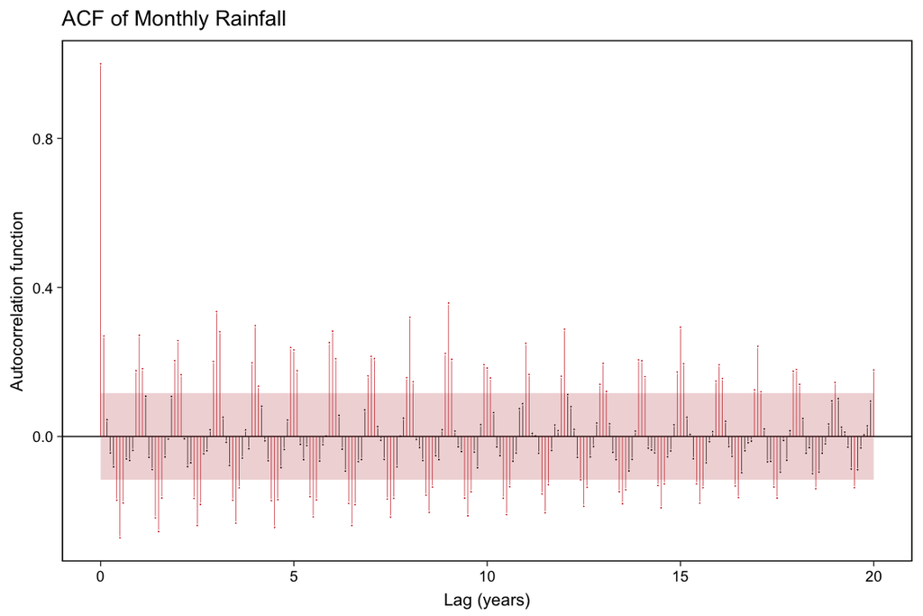

```r
rain_monthly_acf <- acf(rain_monthly$rain_monthly, lag.max = 240, plot = FALSE)
rain_monthly_acf <- data_frame(lag = rain_monthly_acf$lag[,,1],
                               acf = rain_monthly_acf$acf[,,1])

ci <- 0.99
crit <- qnorm((1 + ci)/2)

rain_monthly_acf$sig <- abs(rain_monthly_acf$acf) > crit/sqrt(nrow(rain_monthly))

ggplot(rain_monthly_acf) +
  geom_segment(aes(x = lag / 12, xend = lag / 12, y = acf, yend = 0, color = sig),
               size = 0.25) +
  geom_point(aes(x = lag / 12, y = acf, fill = sig),
             shape = 21, color = "white", size = 0.75) +
  geom_hline(yintercept = 0) +
  geom_ribbon(aes(x = lag / 12, ymin = crit/sqrt(nrow(rain_monthly)),
                  ymax = -crit/sqrt(nrow(rain_monthly))),
              fill = "firebrick", alpha = 0.2) +
  scale_fill_manual(values = c("black", "firebrick3"), guide = FALSE) +
  scale_color_manual(values = c("black", "firebrick3"), guide = FALSE) +
  theme_journal_x2() +
  labs(x = "Lag (years)", y = "Autocorrelation function",
       title = "ACF of Monthly Rainfall")
```

### Monthly rainfall anomalies

Things get more interesting when we look at monthly rainfall anomalies. This is the difference between how much rain *actually* fell in a particular month and how much rain *typically* falls during that month, based on the long-term mean of the entire data set. In essence, we have removed seasonality from the time series, so that we’re now focusing only on deviations from the normal seasonal pattern.

In the plot below, we see the expected correlation of 1 at lag 0, but no strong and consistent pattern of autocorrelation at greater lags. There are a few points that just barely peek out above the critical region, but we can probably attribute these to statistical noise given the large number of lags considered.

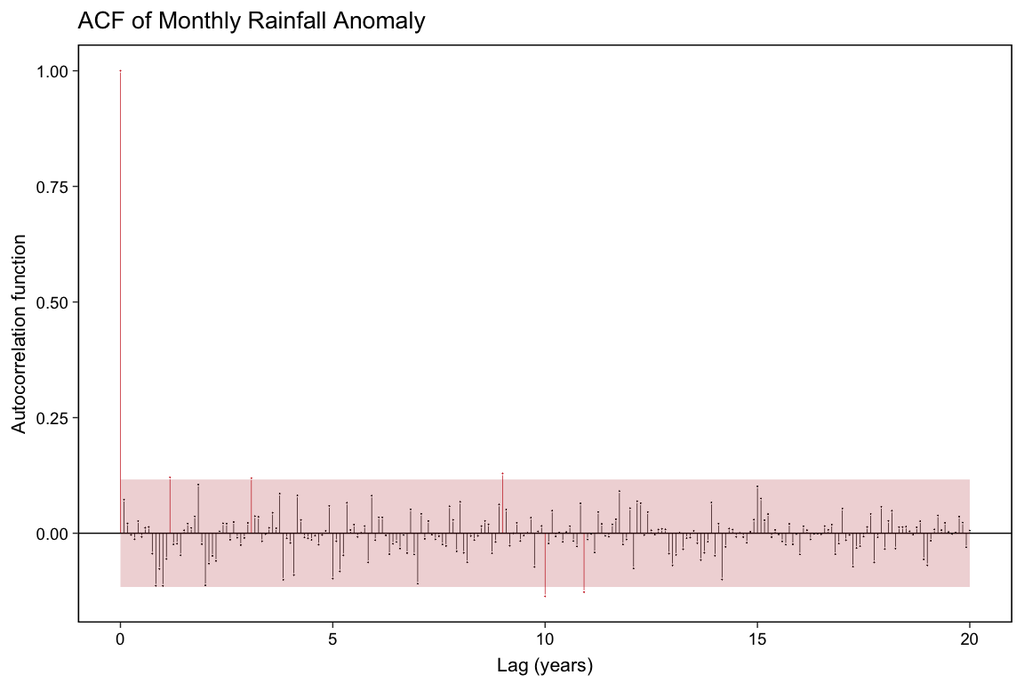

```r
rain_anomaly_acf <- acf(rain_monthly$rain_anomaly, lag.max = 240, plot = FALSE)
rain_anomaly_acf <- data_frame(lag = rain_anomaly_acf$lag[,,1],
                       acf = rain_anomaly_acf$acf[,,1])

rain_anomaly_acf$sig <- abs(rain_anomaly_acf$acf) > crit/sqrt(nrow(rain_monthly))

ggplot(rain_anomaly_acf) +
  geom_segment(aes(x = lag / 12, xend = lag / 12, y = acf, yend = 0, color = sig),
               size = 0.25) +
  geom_point(aes(x = lag / 12, y = acf, fill = sig),
             shape = 21, color = "white", size = 0.75) +
  geom_hline(yintercept = 0) +
  geom_ribbon(aes(x = lag / 12, ymin = crit/sqrt(nrow(rain_monthly)),
                  ymax = -crit/sqrt(nrow(rain_monthly))),
              fill = "firebrick", alpha = 0.2) +
  scale_fill_manual(values = c("black", "firebrick3"), guide = FALSE) +
  scale_color_manual(values = c("black", "firebrick3"), guide = FALSE) +
  theme_journal_x2() +
  labs(x = "Lag (years)", y = "Autocorrelation function",
       title = "ACF of Monthly Rainfall Anomaly")
```

### Total annual rainfall

Finally, we look at autocorrelation in total annual rainfall. There is no significant autocorrelation at any lags > 0.

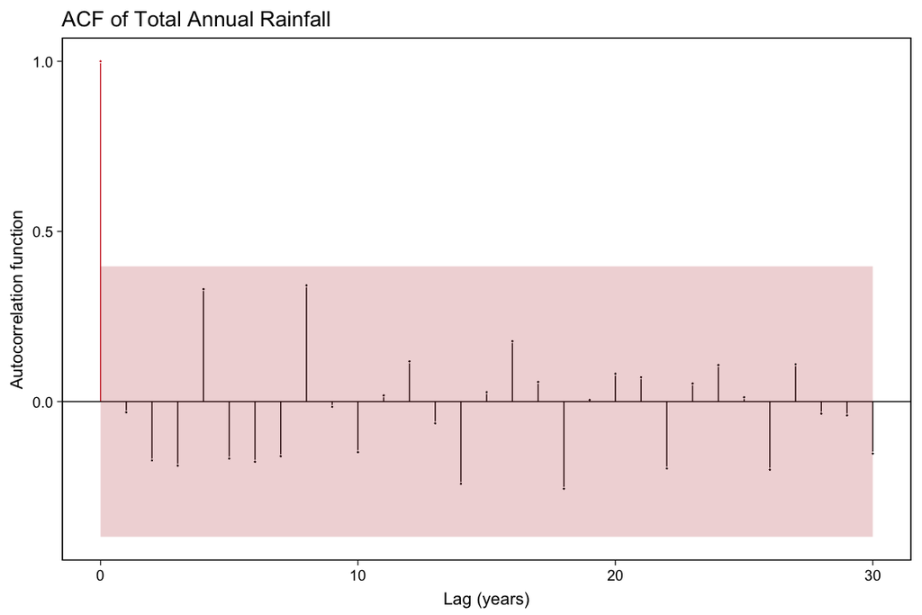

```r
rain_annual_acf <- acf(rain_annual$rain_annual, lag.max = 30, plot = FALSE)

rain_annual_acf <- data_frame(lag = rain_annual_acf$lag[,,1],
                              acf = rain_annual_acf$acf[,,1])

rain_annual_acf$sig <- abs(rain_annual_acf$acf) > crit/sqrt(nrow(rain_annual))

ggplot(rain_annual_acf) +
  geom_segment(aes(x = lag, xend = lag, y = acf, yend = 0, color = sig),
               size = 0.5) +
  geom_point(aes(x = lag, y = acf, fill = sig),
             shape = 21, color = "white", size = 1) +
  geom_hline(yintercept = 0) +
  geom_ribbon(aes(x = lag, ymin = crit/sqrt(nrow(rain_annual)),
                  ymax = -crit/sqrt(nrow(rain_annual))),
              fill = "firebrick", alpha = 0.2) +
  scale_fill_manual(values = c("black", "firebrick3"), guide = FALSE) +
  scale_color_manual(values = c("black", "firebrick3"), guide = FALSE) +
  theme_journal_x2() +
  labs(x = "Lag (years)", y = "Autocorrelation function",
       title = "ACF of Total Annual Rainfall")
```